# NAITRE Trial Mortality Analysis

CONFIDENTIAL. DO NOT DISTRIBUTE.

Prepared by: Fanice Nyatigo, and Benjamin Arnold F.I. Proctor Foundation, University of California, San Francisco

updated: 2022-01-18 11:58:34

# Summary

This report includes unmasked results from the NAITRE trial (NCT03682653).

The report summarizes mortality outcomes in the trial.

Should you have any questions regarding this report, please write Dr. Benjamin Arnold (ben.arnold@ucsf.edu).

# Preamble

```r
#------------------------------
# load configuration file
# includes packages and masked
# assignments
#------------------------------
library(here)
source(here("NAITRE-primary/R","NAITRE-primary-Config.R"))

#--------------------------------
# set up for parallel computing
#--------------------------------
registerDoParallel(cores = detectCores() - 1)
```

# Load the analysis data

```r
#------------------------------
# read in the clean data
# rename public ID to childID
#------------------------------

# primary analysis file
df_analysis <- read_rds(here("NAITRE-primary/data/final","NAITRE_primary_analysis_public.rds")) %>%
  rename(childID = id_public)
```

# Effect on mortality by 6 months

Cumulative incidence of mortality by 6 months is the trial’s primary endpoint.

### Vital status at 6-months

```r
#-------------------------------
# use the final child status
# by 6 months dataset assembled
# above for the CONSORT flow
#
# reverse the tx ordering
# for table1
#-------------------------------
df_analysis %>%
  mutate(tx_table1 = factor(tx, levels = c("Azithromycin","Placebo"))
         ) %>%
  set_variable_labels(vital_180 = "Vital Status at 6 months") %>%
  table1(~ vital_180 | tx_table1, data = .)
```

|  | Azithromycin (N=10898) | Placebo (N=10934) | Overall (N=21832) |
| --- | --- | --- | --- |
| Vital Status at 6 months |  |  |  |
| Alive | 10411 (95.5%) | 10439 (95.5%) | 20850 (95.5%) |
| Dead | 42 (0.4%) | 50 (0.5%) | 92 (0.4%) |
| Unknown | 445 (4.1%) | 445 (4.1%) | 890 (4.1%) |

### Vital status at 6-months, in-window

```r
#-------------------------------
# use the final child status
# by 6 months dataset restricted
# to measurements in-window
# age 6 months +/- 6 weeks
#
# reverse the tx ordering
# for table1
#-------------------------------
df_analysis %>%
  filter(death_status_180 %in% c("Measured, in-window", "Event prior to window")) %>%
  mutate(tx_table1 = factor(tx, levels = c("Azithromycin","Placebo"))) %>%
  set_variable_labels(vital_180 = "Vital Status at 6 months among measurements in-window") %>%
  table1(~ vital_180 | tx_table1, data = .)
```

|  | Azithromycin (N=9606) | Placebo (N=9684) | Overall (N=19290) |
| --- | --- | --- | --- |
| Vital Status at 6 months among measurements in-window |  |  |  |
| Alive | 9564 (99.6%) | 9634 (99.5%) | 19198 (99.5%) |
| Dead | 42 (0.4%) | 50 (0.5%) | 92 (0.5%) |
| Unknown | 0 (0%) | 0 (0%) | 0 (0%) |

### Hazard ratio permutation distribution

Manually code the permutation test for the log(HR). This code was folded into a function, `calc_ratio_pval()`, that is used for all primary inference. Retain the original here for internal comparison.

```r
#-------------------------------
# use the final child status
# by 6 months
#
# set children with Moved
# or Unknown status to missing
#
# They will thus be excluded
# from the HR model estimates
# and permutation test
#-------------------------------
model_df <- df_analysis %>%
  filter(death_status_180 %in% c("Measured, in-window", "Event prior to window"))

#-------------------------------
# run the model
#-------------------------------
mod_empir <- glm(death_response_180 ~ tx, data = model_df, family = binomial(link = cloglog))

# save a model summary
mod_summary <- summary(mod_empir)

# save the log HR and its SE
coef_empir <- mod_summary$coef[2,1]
se_empir <- mod_summary$coef[2,2]

# calculate the upper and lower limits on the HR ratio (coefficient from the model)
upper_empir <- exp(coef_empir+(1.96*se_empir)) %>% round(3)
lower_empir <- exp(coef_empir-(1.96*se_empir)) %>% round(3)
coef_empir_exp <- exp(coef_empir) %>% round(3)
```

```r
#-------------------------------
# permute the treatment allocation and rerun the model to
# estimate distribution of the model coefficient under the Null
#-------------------------------
vitalstatus <- model_df$death_response_180
tx_alloc <- model_df$tx

Npermute <- 10000
null_vec <- foreach(simi = 1:Npermute, .combine = rbind) %dopar% {
  set.seed(simi)

  # pull random numbers the length of treatment vector from uniform distribution 0-1
  reshuffle_vec <- runif(length(tx_alloc))

  # reshuffle the treatment allocation based on random numbers generated
  shuffled_tx <- tx_alloc[order(reshuffle_vec)]

   # subset to non-missing obs
  vitalstatusi <- vitalstatus[!is.na(vitalstatus)]
  shuffled_tx <- shuffled_tx[!is.na(vitalstatus)]

  # run the model on shuffled allocation
  modi <- glm(vitalstatusi ~ shuffled_tx, family = binomial(link = "cloglog"))

  # extract and save the coefficient
  return(modi$coefficients[2])

}

#-------------------------------
# calculate the 2-sided
# permutation test p-value
#-------------------------------
p_value <- sum(abs(null_vec) > abs(coef_empir)) / length(null_vec)
```

Permutation distribution of the log hazard ratio under the null hypothesis. The vertical black line represents the estimated log hazard ratio using the actual treatment assignments.

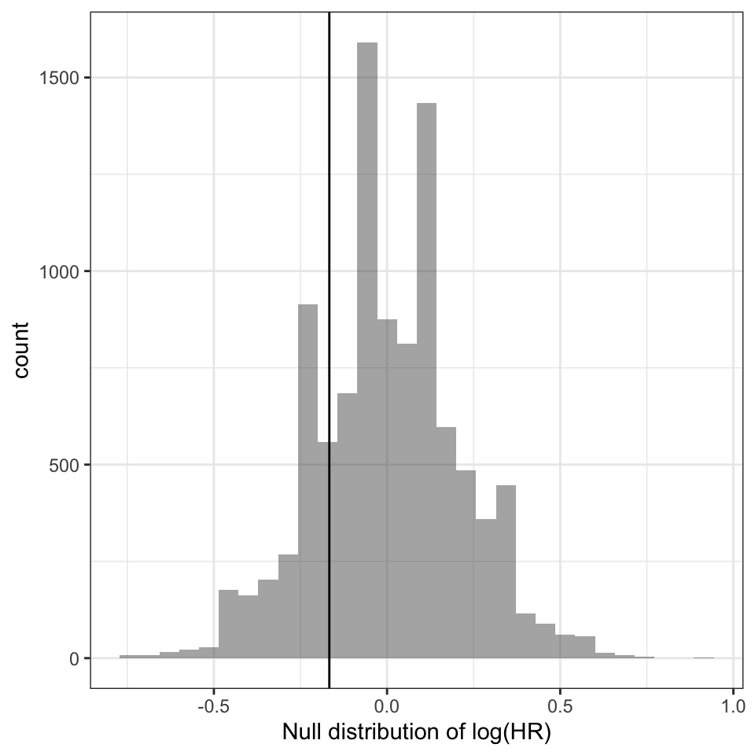

Permutation test two-sided p-value: 0.46

### Mortality comparison

Repeat the analysis, using the general functions that are used throughout the primary, secondary, and subgroup analyses for internal comparison.

```r
#-------------------------------
# summary of children and deaths
#-------------------------------
df_inwindow180 <- df_analysis %>%
  filter(death_status_180 %in% c("Measured, in-window", "Event prior to window"))

df_mortality <-
  calc_ratio_pval(df = df_inwindow180,
                  var = "6-month mortality",
                  outcome = death_response_180,
                  dist_link = "binomial_clglg",
                  N = Npermute) %>%
  mutate(ratio = paste0(sprintf("%1.2f",ratio), " (",
                     sprintf("%1.2f",lower), " to ",
                     sprintf("%1.2f",upper), ")")) %>%
  select(-c(coef, lower, upper))

# render table
knitr::kable(df_mortality,
             digits = 2,
             col.names = c("Outcome", "N Children", "N Deaths", "%", "N Children",
                     "N Deaths", "%", "HR (95% CI)", "P-value*"),
             caption = "Cumulative incidence of mortality by 6 months and hazard ratio (HR) for comparison between arms in children measured within the pre-specified 225-day window, estimated using binomial regression with a complementary log-log link."
      ) %>%
  kable_styling(bootstrap_options = "striped",full_width = TRUE) %>%
  add_header_above(c(" " = 1, "Azithromycin" = 3, "Placebo" = 3, " " = 2)) %>%
  footnote(symbol = c("Permutation P-value (10,000 replicates)"))
```

Cumulative incidence of mortality by 6 months and hazard ratio (HR) for comparison between arms in children measured within the pre-specified 225-day window, estimated using binomial regression with a complementary log-log link.

| Outcome | Azithromycin N Children | Azithromycin N Deaths | Azithromycin % | Placebo N Children | Placebo N Deaths | Placebo % | HR (95% CI) | P-value* |
| --- | --- | --- | --- | --- | --- | --- | --- | --- |
| 6-month mortality | 9606 | 42 | 0.44% | 9684 | 50 | 0.52% | 0.85 (0.56 to 1.28) | 0.46 |

* Permutation P-value (10,000 replicates)

### Sensitivity Analysis

Conduct a sensitivity analysis that includes children who were still measured at 6 months, but were measured out of window.

This includes 1,652 additional children but none of them died by the 6-month visit. Therefore, estimates are nearly identical to the primary analysis.

```r
df_all180 <- df_analysis %>%
  filter(death_status_180 %in% c("Measured, out-of-window", "Measured, in-window", "Event prior to window"))

df_survival <-
  calc_ratio_pval(df = df_all180,
                  var = "6-month mortality",
                  outcome = death_response_180,
                  dist_link = "binomial_clglg",
                  N = Npermute) %>%
  mutate(ratio = paste0(sprintf("%1.2f",ratio), " (",
                     sprintf("%1.2f",lower), " to ",
                     sprintf("%1.2f",upper), ")")) %>%
  select(-c(coef, lower, upper))

# render table
knitr::kable(df_survival,
             digits = 2,
             col.names = c("Outcome", "N Children", "N Deaths", "%", "N Children",
                     "N Deaths", "%", "HR (95% CI)", "P-value*"),
             caption = "Cumulative incidence of mortality by 6 months and hazard ratio (HR) for comparison between arms including the children measured out of the 225-day window, estimated using binomial regression with a complementary log-log link."
      ) %>%
  kable_styling(bootstrap_options = "striped",full_width = TRUE) %>%
  add_header_above(c(" " = 1, "Azithromycin" = 3, "Placebo" = 3, " " = 2)) %>%
  footnote(symbol = c("Permutation P-value (10,000 replicates)"))
```

Cumulative incidence of mortality by 6 months and hazard ratio (HR) for comparison between arms including the children measured out of the 225-day window, estimated using binomial regression with a complementary log-log link.

| Outcome | Azithromycin N Children | Azithromycin N Deaths | Azithromycin % | Placebo N Children | Placebo N Deaths | Placebo % | HR (95% CI) | P-value* |
| --- | --- | --- | --- | --- | --- | --- | --- | --- |
| 6-month mortality | 10453 | 42 | 0.40% | 10489 | 50 | 0.48% | 0.84 (0.56 to 1.27) | 0.42 |

* Permutation P-value (10,000 replicates)